# TB Burden Country Analysis Report

Miles Chang

02-05-2025

## Reading and Preparing Data

```r
library(tidyverse)
library(scales)
library(stats)
library(corrplot)
library(car)
library(cluster)
library(plotly)

# Load TB dataset
tb_data <- read.csv("TB_Burden_Country.csv", stringsAsFactors = FALSE)

# Filter for latest available year in dataset
latest_year <- max(tb_data$Year, na.rm = TRUE)
tb_latest <- tb_data %>% filter(Year == latest_year)

# Select and clean relevant columns
tb_clean <- tb_latest %>%
  select(
    country = `Country.or.territory.name`,
    population = `Estimated.total.population.number`,
    prevalence_per_100k = `Estimated.prevalence.of.TB..all.forms..per.100.000.population`,
    mortality_per_100k = `Estimated.mortality.of.TB.cases..all.forms..excluding.HIV..per.100.000.population`,
    incidence_per_100k = `Estimated.incidence..all.forms..per.100.000.population`,
    hiv_percent = `Estimated.HIV.in.incident.TB..percent.`,
    case_detection_rate = `Case.detection.rate..all.forms...percent`
  ) %>%
  drop_na()

# Rename long country name
tb_clean$country[tb_clean$country == "Democratic People's Republic of Korea"] <- "Korea"
```

## Correlation Analysis

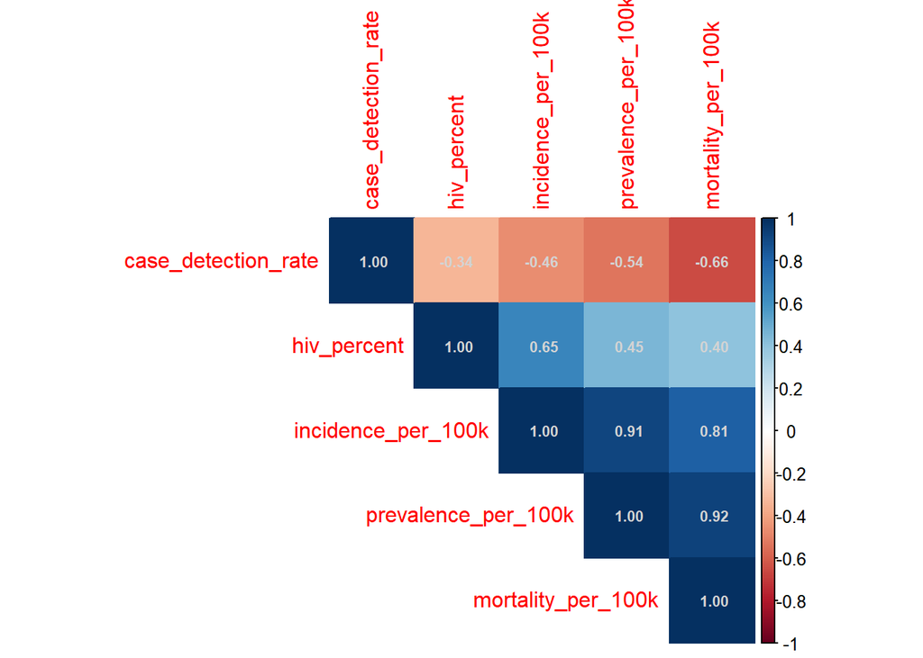

```r
numeric_vars <- tb_clean %>%
  select(prevalence_per_100k, mortality_per_100k, incidence_per_100k, hiv_percent, case_detection_rate)

correlation_matrix <- cor(numeric_vars, use = "complete.obs")
corrplot(correlation_matrix, method = "color",
         type = "upper", order = "hclust",
         addCoef.col = "light grey", number.cex = 0.7)
```

A strong positive correlation indicates that countries with higher TB incidence per 100,000 also tend to have higher mortality rates. This suggests that TB control efforts are crucial in high-incidence settings.

Prevalence and incidence are highly correlated as well since countries with more new cases usually have more existing cases

HIV prevalence among TB patients and TB incidence are moderately correlated which suggests an increasing relationship between these two variables. This could be due to HIV’s role in weakening immunity and increasing vulnerability to TB.

The moderate negative correlation between case detection rate and mortality rate suggests that higher detection helps reduce mortality, but this may vary across countries based on healthcare quality.

## Regression Analysis

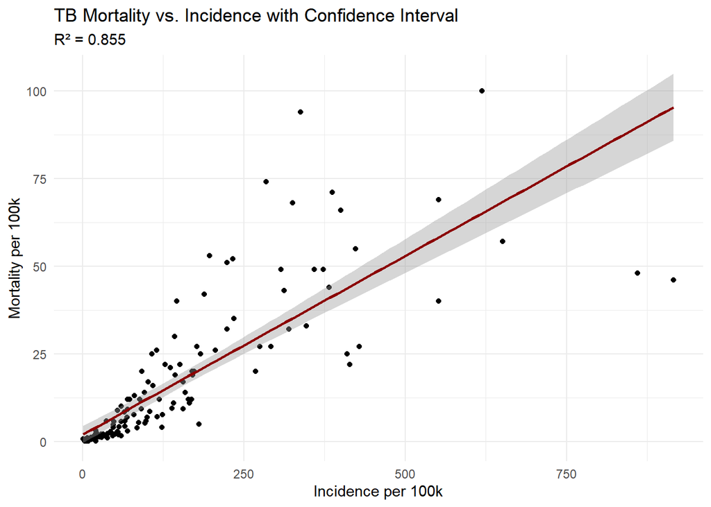

```r
lm_model1 <- lm(mortality_per_100k ~ incidence_per_100k + hiv_percent + prevalence_per_100k, data = tb_clean)
cooks_d <- cooks.distance(lm_model1)
outlier <- which(cooks_d > 1)
tb_clean_no_outlier <- tb_clean[-outlier, ]

lm_model2 <- lm(mortality_per_100k ~ incidence_per_100k + hiv_percent + prevalence_per_100k, data = tb_clean_no_outlier)
model_summary <- summary(lm_model2)
conf_intervals <- confint(lm_model2)

regression_plot <- ggplot(tb_clean_no_outlier, aes(x = incidence_per_100k, y = mortality_per_100k)) +
  geom_point() +
  geom_smooth(method = "lm", se = TRUE, color = "darkred") +
  theme_minimal() +
  labs(title = "TB Mortality vs. Incidence with Confidence Interval",
       subtitle = paste("R² =", round(model_summary$r.squared, 3)),
       x = "Incidence per 100k", y = "Mortality per 100k")

regression_plot
```

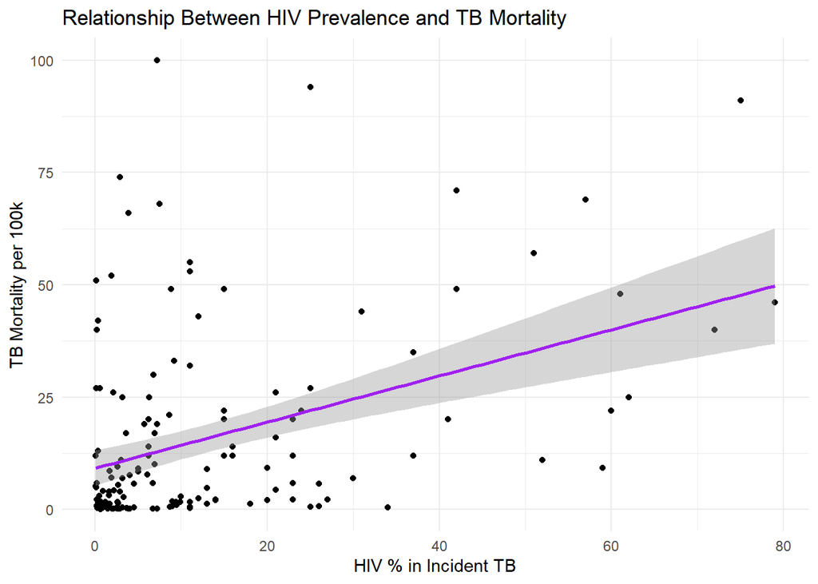

```r
hiv_mortality_plot <- ggplot(tb_clean, aes(x = hiv_percent, y = mortality_per_100k)) +
  geom_point() +
  geom_smooth(method = "lm", se = TRUE, color = "purple") +
  theme_minimal() +
  labs(
    title = "Relationship Between HIV Prevalence and TB Mortality",
    x = "HIV % in Incident TB",
    y = "TB Mortality per 100k"
  )

hiv_mortality_plot
```

```r
model_summary
```

```
##
## Call:
## lm(formula = mortality_per_100k ~ incidence_per_100k + hiv_percent +
##     prevalence_per_100k, data = tb_clean_no_outlier)
##
## Residuals:
##     Min      1Q  Median      3Q     Max
## -22.878  -2.688   0.737   1.963  65.447
##
## Coefficients:
##                     Estimate Std. Error t value Pr(>|t|)
## (Intercept)         -2.82127    0.96629  -2.920 0.004052 **
## incidence_per_100k  -0.05664    0.01459  -3.881 0.000156 ***
## hiv_percent          0.14792    0.06161   2.401 0.017599 *
## prevalence_per_100k  0.14362    0.01114  12.890  < 2e-16 ***
## ---
## Signif. codes:  0 '***' 0.001 '**' 0.01 '*' 0.05 '.' 0.1 ' ' 1
##
## Residual standard error: 7.835 on 148 degrees of freedom
## Multiple R-squared:  0.8551, Adjusted R-squared:  0.8521
## F-statistic:   291 on 3 and 148 DF,  p-value: < 2.2e-16
```

```r
conf_intervals
```

```
##                           2.5 %      97.5 %
## (Intercept)         -4.73078419 -0.91175466
## incidence_per_100k  -0.08547059 -0.02780074
## hiv_percent          0.02616729  0.26966658
## prevalence_per_100k  0.12160116  0.16563540
```

The multiple R-squared indicates that 85.5% of the variation in TB mortality rate is explained by incidence rate, HIV prevalence among TB cases, and TB prevalence rate. Since all explanatory variables have statistically significant p-values, this suggests that each variable contributes meaningfully to explaining TB mortality.

Both regression plot suggests an increasing relationship of TB mortality rate as each explanatory variable increase. While incidence rate have a stronger relationship with TB mortality rate compare to HIV prevalence in TB cases.